# SBCRT_Case_Study

7 December 2016

# Case study with PCA and sPLS-DA on SRBCT data set

Here, we illustrate multilevel PCA and sPLS-DA using the SRBCT data set, see *?srbct*. The Small Round Blue Cell Tumors (SRBCT) dataset from Khan et al. (2001) includes the expression levels of 2308 genes on 63 samples. The samples are distributed in four classes: **8 Burkitt Lymphoma (BL), 23 Ewing Sarcoma (EWS), 12 neuroblastoma (NB), and 20 rhabdomyosarcoma (RMS)**.

## To begin…

Load the latest version of [mixOmics](https://www.rdocumentation.org/link/%20www.mixOmics.org%2FmixMC?package=mixOmics&version=6.0.0).

```r
library(mixOmics)
```

# Data

The srbct dataset contains the following:  
**$gene:** a data frame with 63 rows and 2308 columns. The expression levels of 2,308 genes in 63 subjects. <br> <br> **$class:** a class vector containing the class tumor of each individual (4 classes in total).  
**$gene.name:** a data frame with 2,308 rows and 2 columns containing further information on the genes.

```r
data(srbct)

## The gene expression data
X <- srbct$gene

dim(X)
```

```
## [1]   63 2308
```

# Preliminary analysis with PCA

We start a preliminary investigation with PCA analysis on the gene expression data.

```r
pca.srbct <- pca(X, ncomp = 3, center = TRUE, scale = TRUE)

pca.srbct
```

```
## Eigenvalues for the first 3 principal components, see object$sdev^2:
##      PC1      PC2      PC3
## 258.7304 248.0337 147.5536
##
## Proportion of explained variance for the first 3 principal components, see object$explained_variance:
##        PC1        PC2        PC3
## 0.11210154 0.10746695 0.06393136
##
## Cumulative proportion explained variance for the first 3 principal components, see object$cum.var:
##       PC1       PC2       PC3
## 0.1121015 0.2195685 0.2834998
##
##  Other available components:
##  --------------------
##  loading vectors: see object$rotation
```

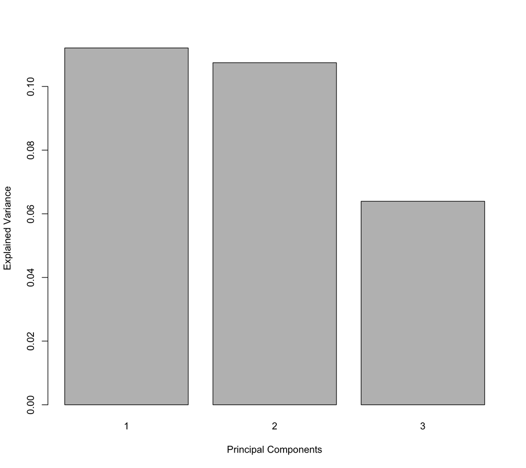

```r
plot(pca.srbct)
```

The PCA numerical output shows that 28% of the total variance is explained with 3 principal components. The barplot above shows the variance explained per component.

Note that it is preferable to first run a PCA with a large number of components (e.g. 10), then visualise on the barplot when the ‘elbow’ (sudden drop) appear to choose the final number of PCs.

We use plotIndiv() to represent the samples on PC1-2 and PC 1-3.

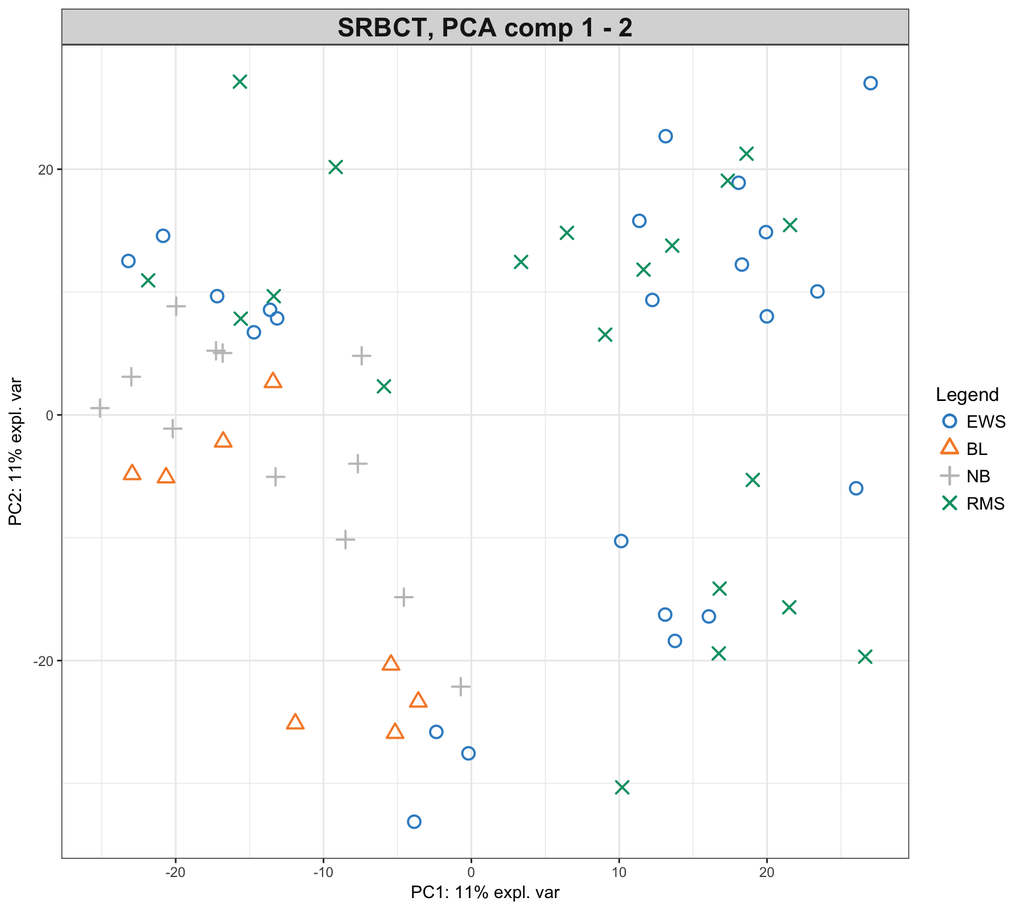

```r
plotIndiv(pca.srbct, group = srbct$class, ind.names = FALSE,
          ellipse = FALSE, legend = TRUE, title = 'SRBCT, PCA comp 1 - 2')
```

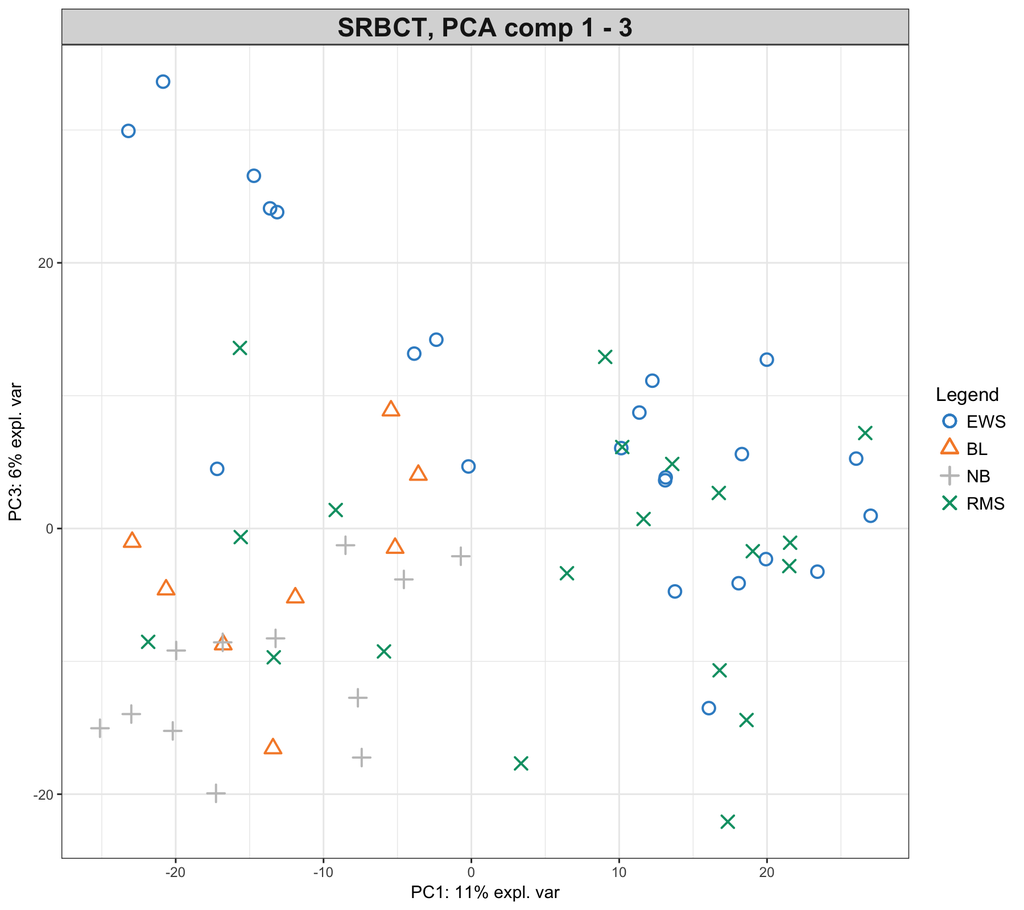

```r
plotIndiv(pca.srbct, comp = c(1,3),
          group = srbct$class, ind.names = FALSE,
          ellipse = FALSE, legend = TRUE, title =  'SRBCT, PCA comp 1 - 3')
```

In the scatterplot above, samples are represented on the first two principal components and colored according to tumour class.We observe that the major source of variation may not be explained by tumour types. There is very little separation between the different tumour type, however we do observe a slight BL+NB cluster vs. most of EWS+RMS.

# PLS-DA analysis

The PLS-DA and sPLS-DA analyses below will help refine the clusters of samples in a supervised fashion. For a supervised analysis, we set up the Y as a factor indicating the class membership of each tumour.

```r
Y <- srbct$class
summary(Y)
```

```
## EWS  BL  NB RMS
##  23   8  12  20
```

## Choosing the number of components…

One practical way to choose the number of components is to run a PLS-DA model first with a large number of components (e.g. *ncomp* = 10 ) using repeated cross-validation (here *folds* = 5 and *nrepeat* = 10 ), then use the function **perf()** which evaluates the performance of the model per component. This step will allow to choose the distance that minimises the classification error rate and the number of optimal components. Our experience has shown that usually *ncomp* = K-1 where K is the number of classes is often optimal, but this is highly dependent on the data.

```r
#this chunk takes ~ 5 min to run
set.seed(32) # for reproducibility of the outputs of this code that performs random cross-validation sampling. To be removed in proper analysis
srbct.plsda.perf <- plsda(X, Y, ncomp = 10)
# to speed up computation in this example we choose 5 folds repeated 10 times:
perf.plsda <- perf(srbct.plsda.perf, validation = 'Mfold', folds = 5,
                   progressBar = FALSE, nrepeat = 10)
```

```r
head(perf.plsda$error.rate)
```

```
## $overall
##         max.dist centroids.dist mahalanobis.dist
## comp 1 0.7768645      0.6161339        0.6161339
## comp 2 0.6691020      0.5111111        0.5188737
## comp 3 0.5662100      0.4785388        0.4937595
## comp 4 0.5124810      0.4611872        0.4680365
## comp 5 0.4707763      0.4283105        0.4406393
## comp 6 0.4768645      0.4336377        0.4366819
## comp 7 0.4526636      0.4310502        0.4248097
## comp 8 0.4400304      0.4272451        0.4266362
##
## $BER
##         max.dist centroids.dist mahalanobis.dist
## comp 1 0.7768645      0.6161339        0.6161339
## comp 2 0.6691020      0.5111111        0.5188737
## comp 3 0.5662100      0.4785388        0.4937595
## comp 4 0.5124810      0.4611872        0.4680365
## comp 5 0.4707763      0.4283105        0.4406393
## comp 6 0.4768645      0.4336377        0.4366819
## comp 7 0.4526636      0.4310502        0.4248097
## comp 8 0.4400304      0.4272451        0.4266362
```

To speed up the computations above we have set up *folds = 5* in the cross-validation (10 would probably be best) and we have set the seed to obtain the same results from one computer/analysis to another. The argument *nrepeat* indicates the number of cross-validation performed, and the performance are averaged across those repeats. Ideally you should choose the folds value so that the learning set is large enough, and so that the test set includes ∼ 5 samples. Also consider increasing nrepeat when folds is small. Alternatively use leave-one-out cross validation *validation = ’loo’* and *nrepeat* is not needed.

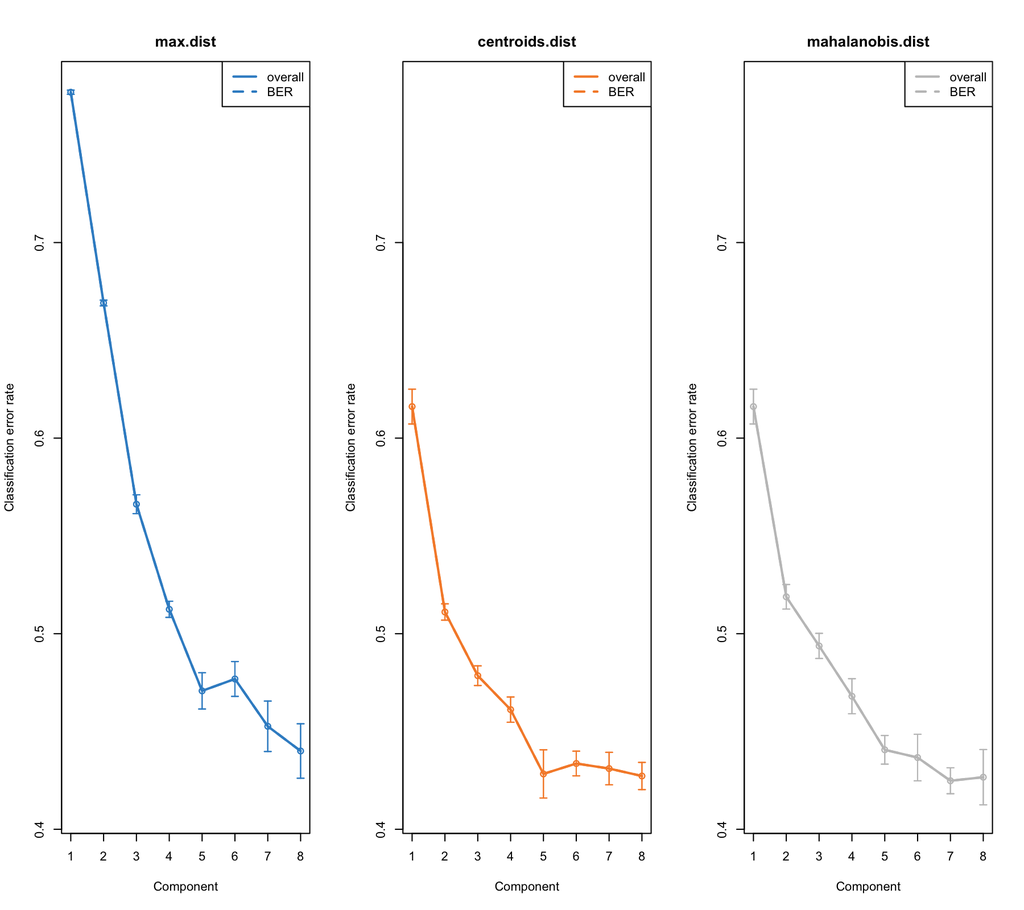

```r
plot(perf.plsda, overlay = 'measure', sd=TRUE)
```

We next fit a smaller PLS-DA model with ncomp = 3 and visualise the samples projected onto these components.

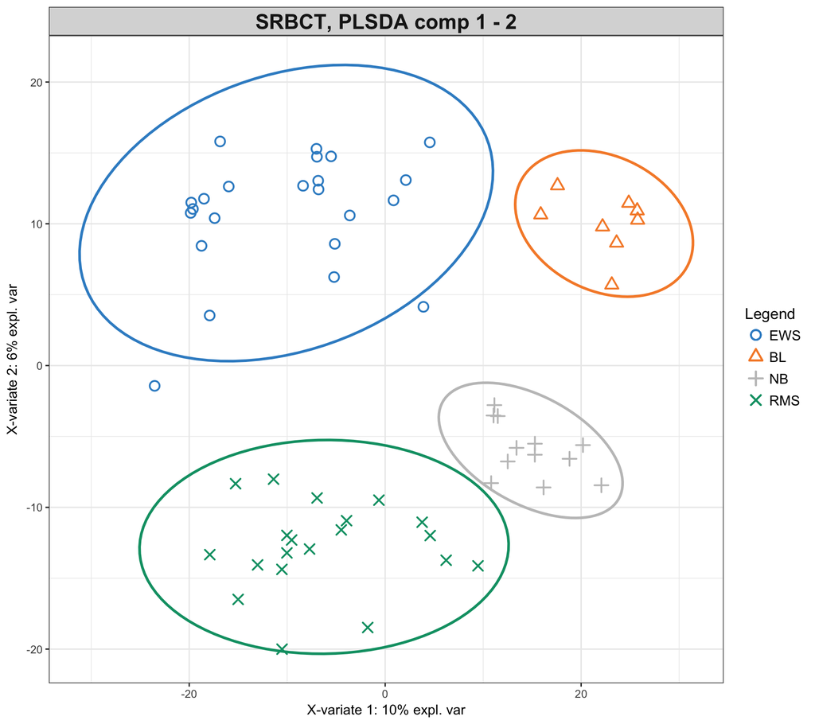

```r
srbct.plsda <- plsda(X, Y, ncomp = 3)

plotIndiv(srbct.plsda , comp = c(1,2),
          group = srbct$class, ind.names = FALSE,
          ellipse = TRUE, legend = TRUE, title = 'SRBCT, PLSDA comp 1 - 2')
```

We observe a clear separation of the four tumor classes compared to an unsupervised PCA sample plot. This is to be expected since the PLS-DA model includes the class information of each individual. Confidence ellipses for each class are plotted to highlight the strength of the discrimination (confidence level set to 0.95 per default). However, we observe many of the 2308 genes in X are noisy or uninformative to characterize the different classes. The sPLS-DA analysis will help refine the sample clusters and select a small subset of variables relevant to discriminate each class.

# sPLS-DA analysis

The PLS-DA model is built on all *ncol(X)* genes in *$X$*, many of which may be uninformative to characterise the different classes. The sPLS-DA analysis will identify a small subset of genes that best discriminate the classes.

## Tuning sPLS-DA

sPLS-DA selects the most predictive/discriminative features in the data that help classifying the samples. sPLS-DA is a special case of sparse PLS, where the l1 penalization is solely applied on the loading vector associated to the X data set, see [3].

**Note:** For a thorough tuning step, the following code should be repeated 50-100 times.

```r
#this chunk takes ~ 6 min to run
set.seed(32) # for reproducibility of the outputs of this code that performs random cross-validation sampling. To be removed in proper analysis
# grid of possible keepX values that will be tested for comp 1 and comp 2
list.keepX <- c(1:10,  seq(20, 100, 10))
# to speed up computation in this example we choose 5 folds repeated 10 times:
tune.splsda.srbct <- tune.splsda(X, Y, ncomp = 5, validation = 'Mfold', folds = 5,
                           progressBar = FALSE, dist = 'mahalanobis.dist',
                           test.keepX = list.keepX, nrepeat = 10) #nrepeat 50-100
```

This output globally shows that 4 components are sufficient to achieve the lowest classification error rate in the sparse model:

```r
head(tune.splsda.srbct$error.rate)
```

```
##       comp1     comp2      comp3       comp4
## 1 0.4706341 0.2231522 0.07414855 0.019067029
## 2 0.4544928 0.2167844 0.05931159 0.013722826
## 3 0.4445109 0.1997283 0.05489130 0.012635870
## 4 0.4224547 0.1818207 0.04630435 0.011548913
## 5 0.4063768 0.1820562 0.04396739 0.008423913
## 6 0.4035417 0.1775181 0.03846014 0.008423913
```

We display the mean classification error rate on each component. Each component is conditional on the previous components calculated with the optimal number of selected variables. The plot shows the `optimal’ number of variables to select as well as the number of components *ncomp*. The diamond on the plot indicates the best *keepX* value to achieve the lowest error rate per component.

```r
tune.splsda.srbct$choice.keepX
```

```
## comp1 comp2 comp3 comp4
##    20    60    40     5
```

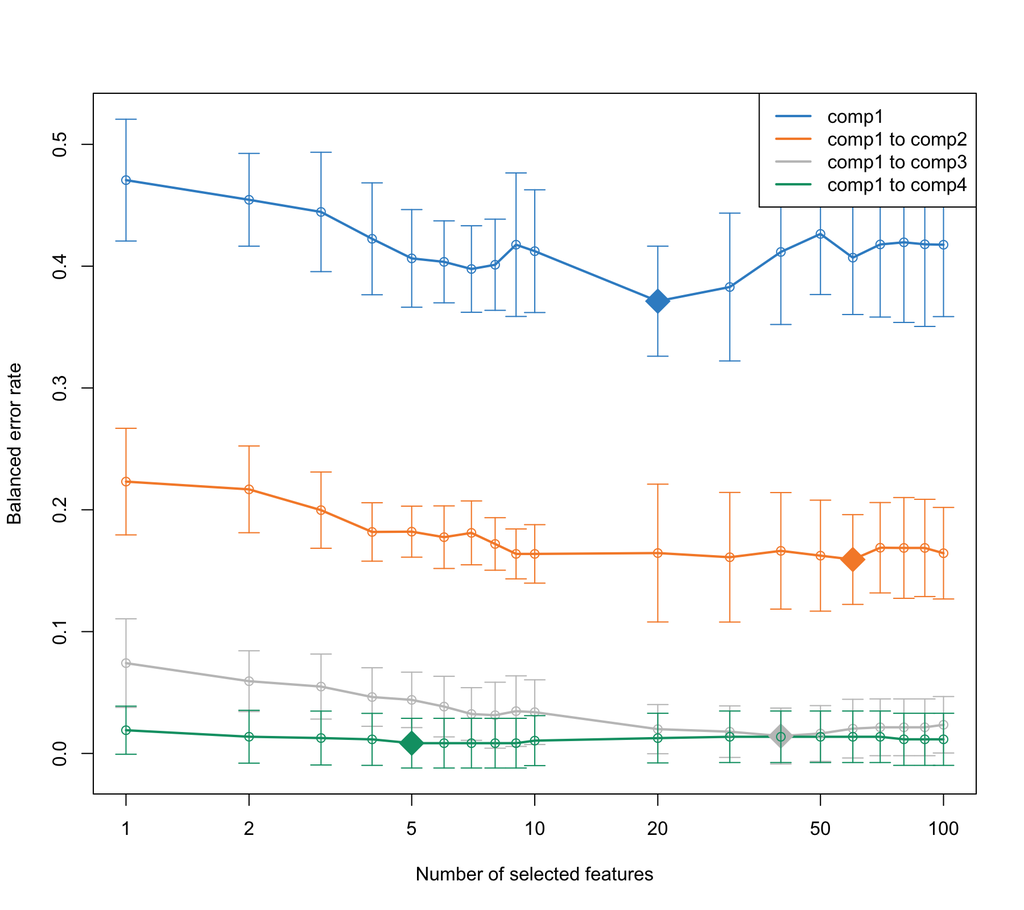

```r
plot(tune.splsda.srbct, optimal = TRUE, sd = TRUE)
```

These results will depend on how fine your tuning grid *list.keepX* is, as well as the values chosen for folds and nrepeat. Therefore the performance of the final model, as well as the stability of the selected variables across the different folds should be examined, see below.

The graphic above shows that the error rate decreases when more components are included in sPLS-DA. To obtain a more reliable estimation of the error rate, the number of repeats should be increased (between 50 to 100). This type of graph helps choosing not only the ‘optimal’ number of variables to select confirm the number of components ncomp . Indeed, when a sufficient number of components have been added, the error rate will stop decreasing. The addition of the fourth component is probably not necessary here as the third and fourth component seem to leave to similar error rates.